# Assignment 1 Solution

Beatrix Jones

20/4/2020

1. Make a boxplot showing all the days, in chronological order (this is the order they are listed). Comment on any trends or outliers. Make sure you have appropriate title and axis labels.

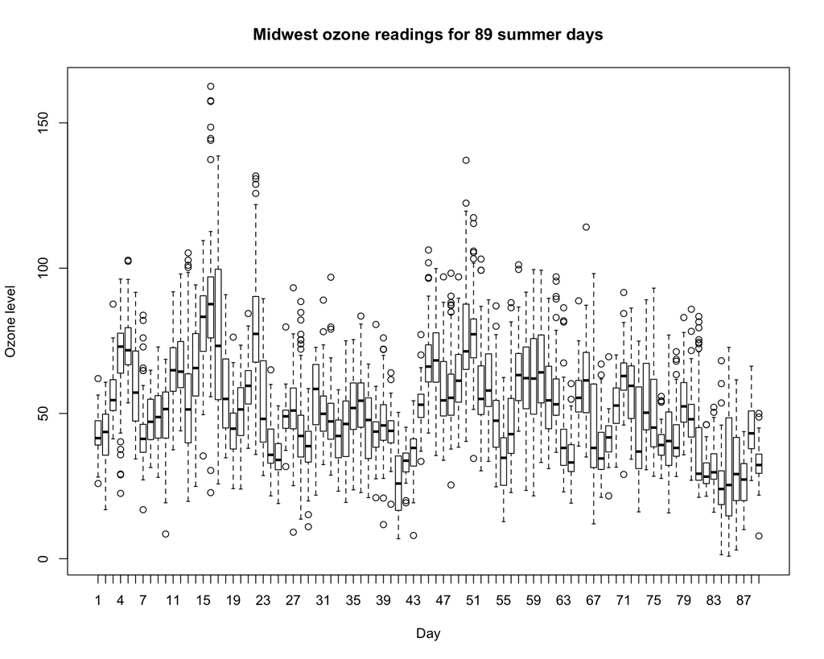

```r
read.csv("../Week1/ozone3.csv")->ozone
boxplot(ozone,names=1:89, xlab="Day", ylab="Ozone level", main="Midwest ozone readings for 89 summer days")
```

The ozone level varies fairly smoothly through time, although there are some sharp changes, e.g from day 42-46. There is an up and down pattern rather than a trend in one direction. Most days have some outliers, but there are no days that stand out as radically diffferent from the others.

2. One way to get a sense of skewness would be to look at the difference between median and mean. Compute this for each day, and make a histogram of the 89 resulting numbers. Comment on any interesting features. If there are outliers, identify them (by observation number) and include a plot of their time series.

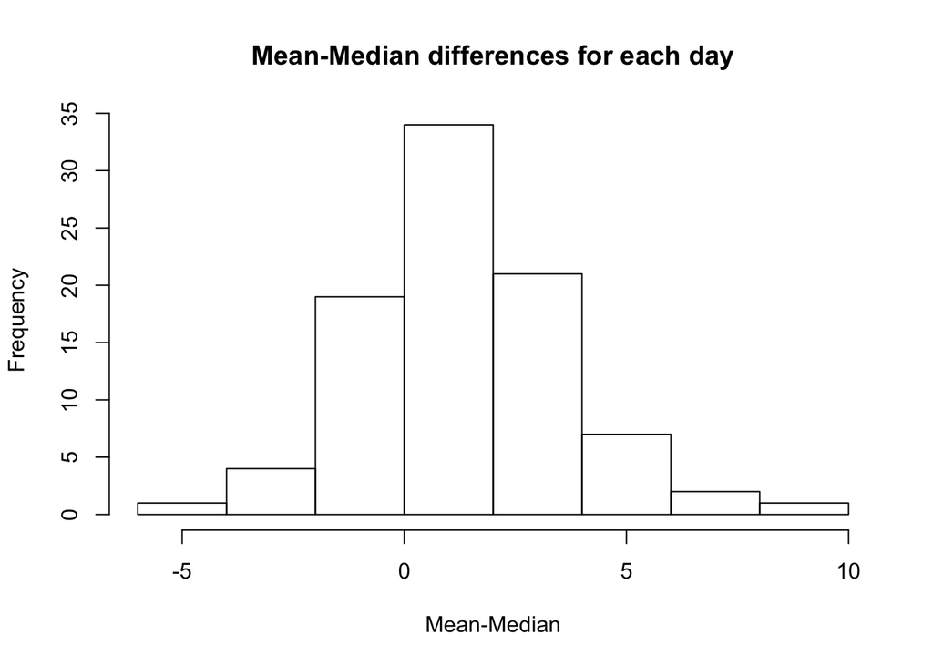

```r
hist(apply(ozone,2,mean)-apply(ozone,2,median), xlab='Mean-Median', main="Mean-Median differences for each day")
```

We see a slightly longer upper tail than lower tail, indicating many days may have a small positive skew (not surprizing for a measurement with a lower bound of zero). There are no outliers.

3. Plot the mean for each day as a time series (joined up by lines).

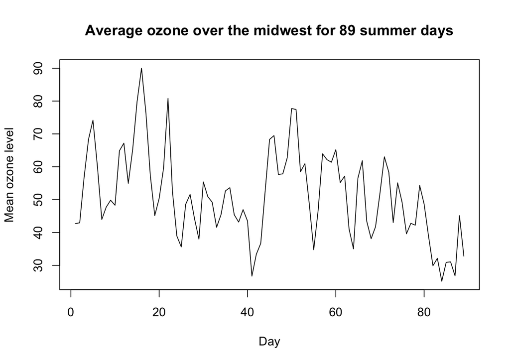

```r
plot(apply(ozone,2,mean), type='l', xlab='Day', ylab='Mean ozone level', main='Average ozone over the midwest for 89 summer days')
```

4. Should we compute the principal components based on the correlation or covariance matrix? Explain your reasoning.

I would use the covariance matrix because the observations are naturally on the same scale. If a particular day has low variance (is always close to the mean) we are quite happy to have that day simply contribute less to our principal components, rather than scaling so variation on that day is represented at a higher resolusion.

5. Make an image plot of your chosen matrix. Comment on any features.

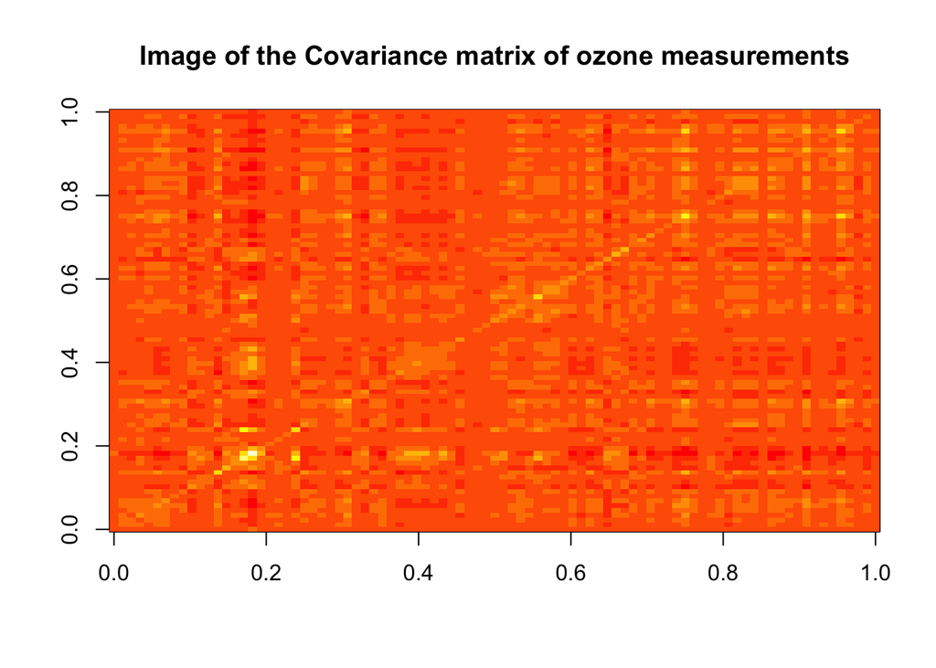

```r
image(cov(ozone), main="Image of the Covariance matrix of ozone measurements")
```

Also fine if you have done the ggplot version of this. There are some bright spots on the diagonal that represent days with higher variance. High correlations between adjacent days would be seen as larger light colored squares or bands around the diagonal. There is perhaps not as much of this as I would’ve expected, but there is some, eg a lighter orange patch starting around time zero, and another around 0.4.

6.Compute the principal components. Show the scree plot. How many components do you think we should use? Explain your reasoning. How much of the variability does this number of components represent?

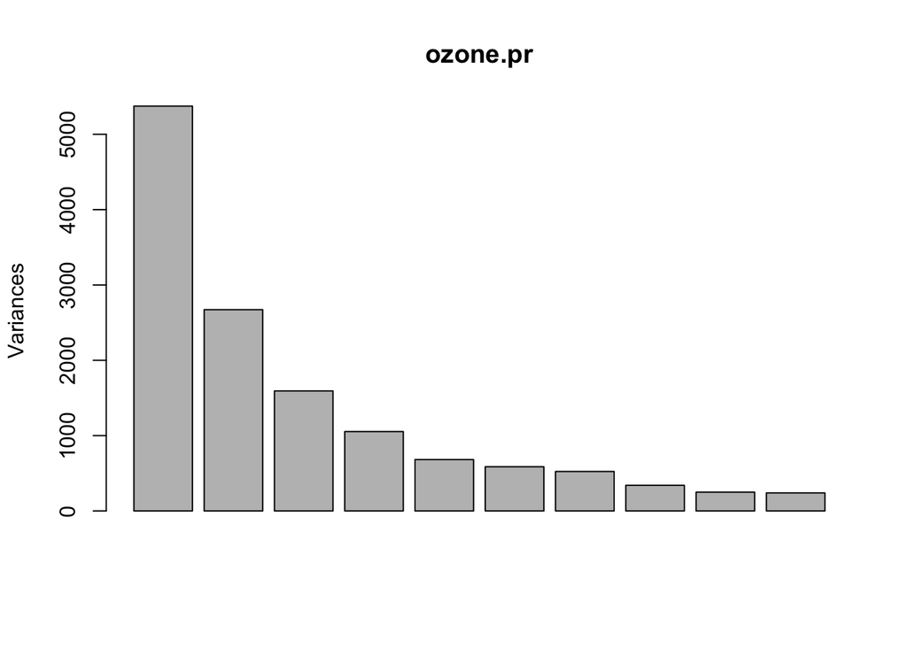

```r
ozone.pr<-prcomp(ozone)
plot(ozone.pr)
```

```r
round(ozone.pr$sdev^2/sum(ozone.pr$sdev^2),2)
```

```
##  [1] 0.34 0.17 0.10 0.07 0.04 0.04 0.03 0.02 0.02 0.02 0.01 0.01 0.01 0.01
## [15] 0.01 0.01 0.01 0.01 0.01 0.01 0.01 0.00 0.00 0.00 0.00 0.00 0.00 0.00
## [29] 0.00 0.00 0.00 0.00 0.00 0.00 0.00 0.00 0.00 0.00 0.00 0.00 0.00 0.00
## [43] 0.00 0.00 0.00 0.00 0.00 0.00 0.00 0.00 0.00 0.00 0.00 0.00 0.00 0.00
## [57] 0.00 0.00 0.00 0.00 0.00 0.00 0.00 0.00 0.00
```

7. Plot the first two principal component scores. Comment on interesting features.

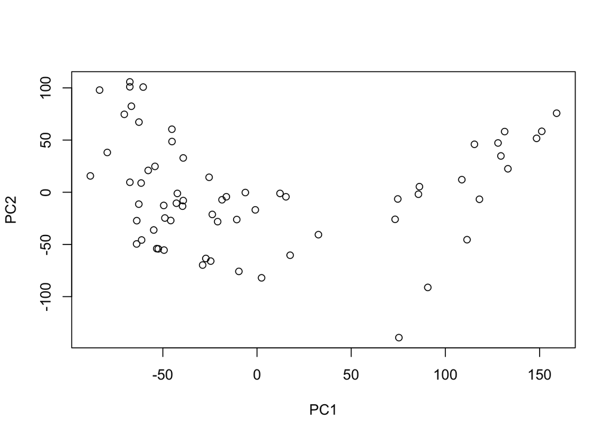

```r
plot(ozone.pr$x[,1:2])
```

We see the two arms of the horseshoe much as we did in class before the removal of outliers. There are two points that are low on PC2 and between 50 and 100 on PC1 that might count at outliers.

8. If there are any outliers, plot the time series for them and comment on how they differ from the mean. If there are groups (or arms of a horseshoe), plot a representative from the center of each group.

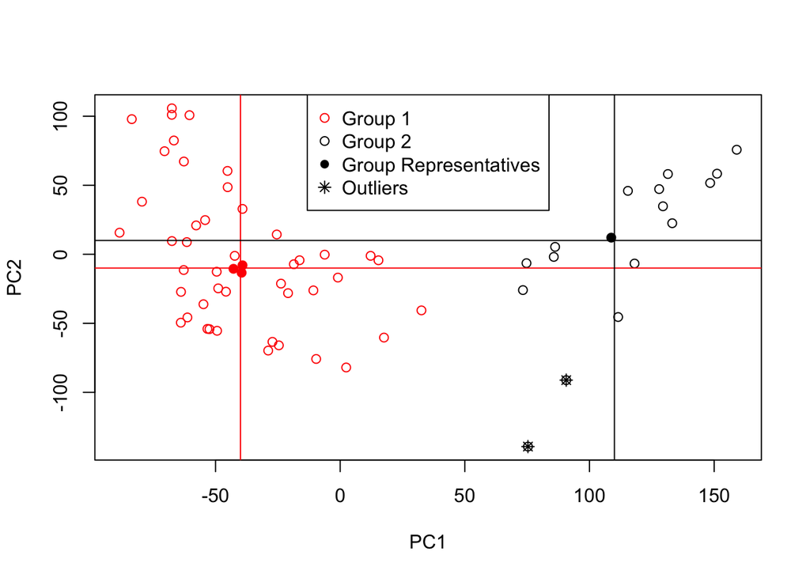

```r
plot(ozone.pr$x[,1:2], col=(ozone.pr$x[,1]<50)+1)
legend('top', legend=c( "Group 1", "Group 2", "Group Representatives", "Outliers"), pch=c(1,1,16,8), col=c(2,1,1,1))
abline(v=-40, col=2)
abline(h=-10, col=2)
index<-which(abs(ozone.pr$x[,1]+40) < 5  & abs(ozone.pr$x[,2]+10)<5)
points(ozone.pr$x[index,1], ozone.pr$x[index,2], pch=16, col=2)
abline(v=110)
abline(h=10)
index2<-which(abs(ozone.pr$x[,1]-110) < 5  & abs(ozone.pr$x[,2]-10)<5)
points(ozone.pr$x[index2,1], ozone.pr$x[index2,2], pch=16)
outliers<-which(ozone.pr$x[,2]< -90)
points(ozone.pr$x[outliers,1], ozone.pr$x[outliers,2], pch=8)
```

There is no need for you to have made a plot like this; I have done it to illustrate finding the coordinates of the points. Using “identify” is more efficient, but does not embed well in a document. I have just picked out group centers and nearby points visually. We will talk about more formal methods for this later in the course.

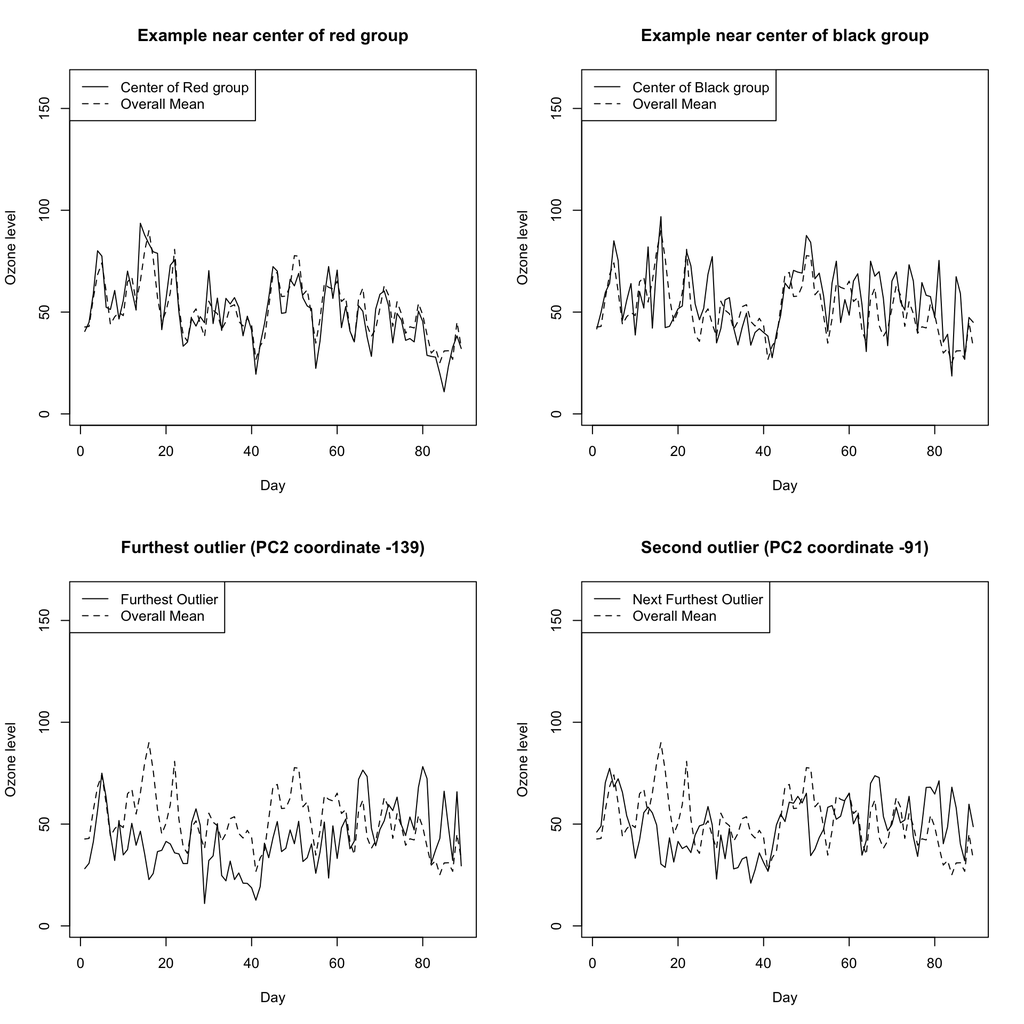

```r
par(mfrow=c(2,2))
plot(1:89,ozone[index[1],], type='l', xlab='Day', ylab='Ozone level', main='Example near center of red group', ylim=range(ozone))
lines(1:89, apply(ozone,2, mean), lty=2)
legend("topleft", lty=c(1,2), legend=c("Center of Red group", "Overall Mean"))
plot(1:89,ozone[index2[1],], type='l', xlab='Day', ylab='Ozone level', main='Example near center of black group', ylim=range(ozone))
lines(1:89, apply(ozone,2, mean), lty=2)
legend("topleft", lty=c(1,2), legend=c("Center of Black group", "Overall Mean"))

plot(1:89,ozone[outliers[1],], type='l', xlab='Day', ylab='Ozone level', main='Furthest outlier (PC2 coordinate -139)', ylim=range(ozone))
lines(1:89, apply(ozone,2, mean), lty=2)
legend("topleft", lty=c(1,2), legend=c("Furthest Outlier", "Overall Mean"))

plot(1:89,ozone[outliers[2],], type='l', xlab='Day', ylab='Ozone level', main='Second outlier (PC2 coordinate -91)', ylim=range(ozone))
lines(1:89, apply(ozone,2, mean), lty=2)
legend("topleft", lty=c(1,2), legend=c("Next Furthest Outlier", "Overall Mean"))
```

We can see the representative of the red group is very similar to the overall mean (makes sense as both PC coordinates are close to zero). The main attribute of the black group seems to be higher ozone later in the summer. As we saw in class these are the more southern points so it would make sense for the summer pattern to last longer here. The outliers are similar to the black group in the late summer, but are distinguished by having lower than average ozone in the early-to-mid summer.